# BACE simulation study: does it recover the truth under missing data?

Published

October 27, 2026

# What changed since the 2026-07 report

Pre-fix outputs are archived in `archive_2026-07_prebugfix/` and compared against below (Section 5.3).

# What changed in 2026-10

A pre-release code review (PR #15; write-up in `.agents/investigation-2026-10.md`) surfaced **five further defects**, all fixed before this render:

1. **Categorical predictions silently dropped all phylogenetic effects** (a BLUP column-name mismatch; the ordinal/threshold path was unaffected). The categorical Study B cells were therefore **regenerated 2026-10-27** on the fixed package with the same seeds; the stale cells are archived in `archive_2026-08_pre-oct-fixes/`. Effect of the fix: accuracy 0.783→0.799 (MCAR) and 0.807→0.815 (MAR); balanced accuracy 0.635→0.651 and 0.628→0.642 (≈90% of the Bayes ceiling, from ≈88%); runtime halved (22→12.5 s/dataset) by the accompanying vectorisation.
2. **The final phase understated imputation uncertainty when two or more variables are missing together** (one pass from a fixed deterministic start) — fixed with within-run Gibbs passes (`sweeps`, default 3, auto-collapsing to a single pass when only one variable is missing). Both studies in this report make only the response missing, so their numbers are unaffected; verified by re-running Study A on the fixed package — identical to the 2026-08 run within 1e-8. A dedicated calibration study (`dev/15_sweeps_calibration.R`; two variables 30% missing each, sweeps ∈ {1,2,3,5,8} paired on identical data) confirmed the default of 3 and quantified the old one-pass behaviour: downstream slope biased upward by ~15% of its true value (incoherent cross-variable draw pairs) and between-imputation variance understated by 13–20%.
3. **Reported class probabilities (`prob_preds`) were plug-in** (posterior-mean coefficients; overconfident by Jensen’s inequality) — now averaged over posterior draws. The discrete `cover95_prob` sets below use the honest averaged probabilities (slightly more conservative: categorical 0.984→0.99).
4. **MCMC diagnostics skipped cutpoints and never ran on the final-phase models** — both now covered (`bace_final_imp()$diagnostics`).
5. **User-supplied priors were silently ignored** — a validated `priors` argument was added; all defaults are unchanged, so nothing else in this report moves.

# 1 Aims

Evaluate whether **BACE recovers the truth** when data are missing: are its imputed values and the parameters estimated from them **unbiased**, are its uncertainty intervals **calibrated**, and does this hold **across response distributions** and **missingness mechanisms**?

# 2 What simulations we did

Two studies, both on `sim_bace()` with production MCMC (`nitt` 4–5k, `burnin` 0.8–1k, `thin` 4–5, `n_final` 15–20).

| Study | Response | Mechanisms | Replicates | Purpose |
| --- | --- | --- | --- | --- |
| **A** | gaussian, known slope | MCAR, MAR | **40** each | parameter recovery: slope bias + CI coverage, vs an oracle and complete-case |
| **B** | gaussian, poisson, binary, ordinal, categorical | MCAR, MAR | **1000** each | value recovery, bias, and interval calibration for every response type |

Study B is 5 types × 2 mechanisms × 1000 reps = **10,000 datasets** (9997 completed).

# 3 Settings, model structure, and provenance

**Simulated model structure.**

- **Study A** (`dev/12_recovery_simulation.R`): pure-birth tree (`ape::rtree`, Grafen branch lengths, depth-normalised to 1); phylogenetically correlated predictor $x \sim \mathrm{MVN}(0, R)$ and phylogenetic effect $u \sim \mathrm{MVN}(0, R)$ on the tree correlation matrix $R$; response $y = b_0 + b_1 x + u + \varepsilon$, $\varepsilon \sim N(0, \sigma_e^2)$ (true values in the table below). Missingness on $y$ only: MCAR at a constant rate; MAR with $\Pr(\text{missing}) = \mathrm{plogis}\{a + \text{mar\_slope}\cdot z(x)\}$ — depends on the *observed* predictor. Analysis pipeline per replicate: `bace_imp()` → `assess_convergence()` → `bace_final_imp()` → `with_imputations(gls)` → `pool_mi()`, against **oracle** (full data) and **complete-case** comparators.
- **Study B** (`dev/13_response_type_simulation.R`, v3): data from `sim_bace()` — one response (gaussian / poisson / binary / `threshold3` ordinal / `multinomial3` categorical) plus two gaussian predictors, all three variables with the phylogenetic-signal proportion below; known predictor effects $\beta_{x_1}, \beta_{x_2}$ (below); one row per species. Discrete responses are generated on the latent liability scale (the multinomial DGP draws distinct per-liability slopes and random effects and records the per-replicate Bayes ceiling). Missingness on the response only, same MCAR/MAR mechanisms as Study A (MAR depends on observed $x_1$).

**Settings actually used** (printed from the saved run objects, so these are the production values, not script defaults):

| Study | Setting | Value |
| --- | --- | --- |
| A | reps | 40 |
| A | nspp | 80 |
| A | nitt | 5000 |
| A | burnin | 1000 |
| A | thin | 5 |
| A | runs | 4 |
| A | n_final | 20 |
| A | b0 | 0 |
| A | b1 | 0.8 |
| A | sigma_e | 0.5 |
| A | miss_rate | 0.3 |
| A | mar_slope | 2 |
| B | reps | 1000 |
| B | nspp | 80 |
| B | nitt | 4000 |
| B | burnin | 800 |
| B | thin | 4 |
| B | runs | 3 |
| B | n_final | 15 |
| B | cores | 7 |
| B | phylo | 0.9 |
| B | rate | 0.3 |
| B | mar_slope | 2 |
| B | beta | 0.9, -0.6 |

**File map** (all under `dev/` unless noted):

| File | Role |
| --- | --- |
| `12_recovery_simulation.R` | Study A generator + analysis (env-var scaled; DGP and pipeline above) |
| `13_response_type_simulation.R` | Study B generator + analysis (resumable per-cell chunks in `simulation_results/response_type_chunks/`) |
| `14_make_simulation_report.R` | per-rep CSV extraction + standalone figures |
| `simulation_results/recovery_simulation.rds` / `response_type_simulation.rds` | full results incl. the `cfg` printed above |
| `simulation_results/recovery_per_rep.csv`, `response_type_per_rep.csv` | per-replicate metrics (what this report plots) |
| `simulation_results/*_summary.csv` | aggregated summaries |
| `simulation_results/archive_2026-07_prebugfix/` | pre-fix run for Section 5.3 |
| `simulation_results/archive_2026-08_pre-oct-fixes/` | 2026-08 outputs archived before the 2026-10 categorical regeneration |
| `.agents/investigation-2026-08.md` | root-cause write-up behind the six fixes |
| `.agents/investigation-2026-10.md` | root-cause write-up behind the five 2026-10 fixes |
| `R/simulate_simBACE.R` (`sim_bace()`) | the Study B data-generating engine |

# 4 Measures (what they mean)

For each replicate we hide 30% of the response, impute with BACE, and compare to the known truth; averages over replicates carry **Monte Carlo standard errors (MCSE)**.

- **Bias** (standardised): $\big(\overline{\hat y} - \overline{y}\big)/\mathrm{SD}(y)$ on hidden cells (**0 = unbiased**); categorical uses total-variation distance of class proportions.
- **Coverage** — two estimators per family:
  - `cover95` *(quantile; kept for comparability with 2026-07)*: truth inside the empirical 2.5–97.5% range of the `n_final` draws. **Ceiling ≈ 0.831 at 15 draws even for a perfect imputer** — read it against that ceiling, not against 0.95.
  - `cover95_t` (continuous): $\bar y_{draws} \pm t_{m-1,.975}\, s_{draws}\sqrt{1+1/m}$ — no finite-draw ceiling; target 0.95. `cover95_prob` (discrete): smallest class set reaching 0.95 cumulative probability under the models’ averaged class-probability matrices; target ≥ 0.95.
- **Recovery**: correlation (continuous; plus Spearman and log1p-scale for poisson, since Pearson on raw counts is tail-dominated) or balanced accuracy (discrete). Categorical is judged **against its per-replicate Bayes ceiling** (`bayes_bal_acc`, computed from the true simulated class probabilities).

# 5 Results

## 5.1 Study A — parameter recovery (gaussian slope, 40 reps)

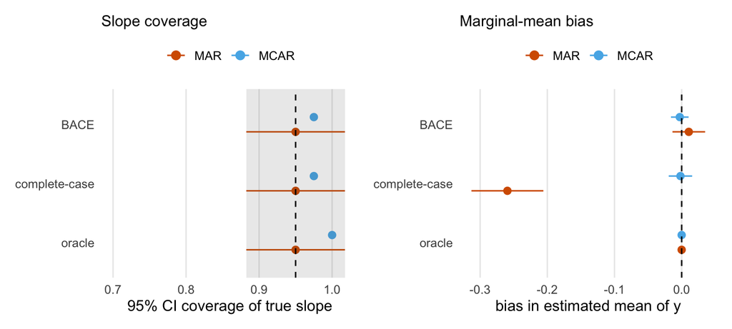

*Grey band = correct-calibration range at 40 reps. Under MAR, complete-case analysis is a biased sample of the response; BACE removes that bias and its 95% CI covers the true slope at the nominal rate.*

| Method | Mech | Slope bias | Coverage | Mean bias |
| --- | --- | --- | --- | --- |
| BACE | MAR | 0.065 | 0.950 | 0.011 |
| complete-case | MAR | 0.098 | 0.950 | -0.259 |
| oracle | MAR | 0.071 | 0.950 | 0.000 |
| BACE | MCAR | 0.070 | 0.975 | -0.003 |
| complete-case | MCAR | 0.045 | 0.975 | -0.002 |
| oracle | MCAR | 0.057 | 1.000 | 0.000 |

## 5.2 Study B — recovery, bias, calibration by response type (1000 reps each)

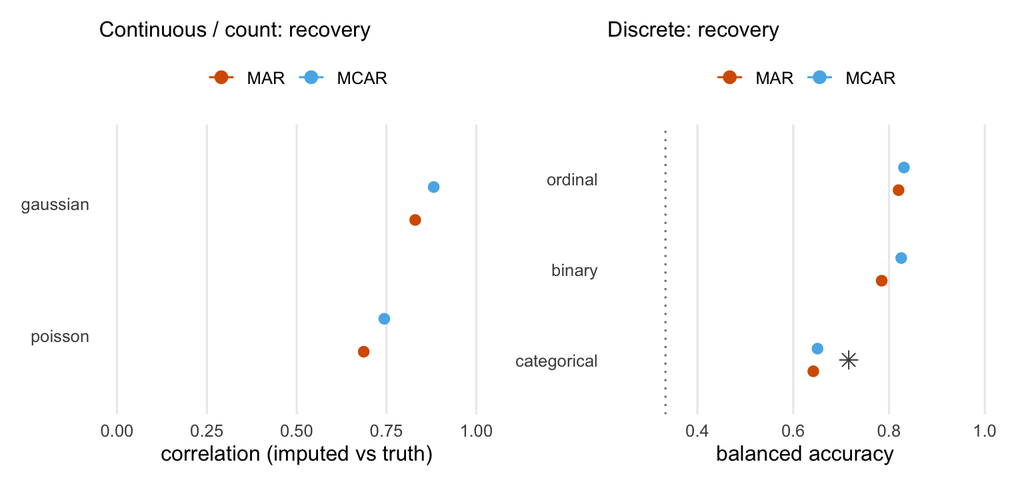

*Dotted line = chance (1/3). Star = the categorical **Bayes-classifier ceiling** given the DGP — balanced accuracy cannot exceed it.*

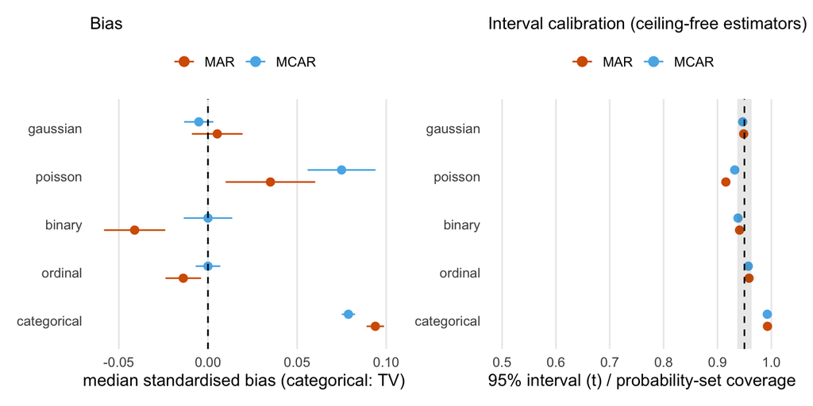

*Calibration uses the ceiling-free estimators: `cover95_t` for gaussian/poisson, `cover95_prob` for binary/ordinal/categorical.*

| Type | Mech | n | Recovery | Rec (Spearman) | Bal.acc | Bayes ceiling | Median bias | Cover (q) | Cover (t) | Cover (prob) | Runtime (s) |
| --- | --- | --- | --- | --- | --- | --- | --- | --- | --- | --- | --- |
| gaussian | MAR | 1000 | 0.830 | 0.795 | NaN | NaN | 0.005 | 0.844 | 0.949 | NaN | 10.2 |
| gaussian | MCAR | 1000 | 0.881 | 0.852 | NaN | NaN | -0.005 | 0.845 | 0.947 | NaN | 10.0 |
| poisson | MAR | 1000 | 0.687 | 0.713 | NaN | NaN | 0.035 | 0.867 | 0.916 | NaN | 12.1 |
| poisson | MCAR | 1000 | 0.744 | 0.706 | NaN | NaN | 0.075 | 0.902 | 0.932 | NaN | 11.9 |
| binary | MAR | 999 | 0.859 | NaN | 0.785 | NaN | -0.041 | 0.983 | NaN | 0.941 | 11.3 |
| binary | MCAR | 1000 | 0.855 | NaN | 0.826 | NaN | 0.000 | 0.981 | NaN | 0.938 | 11.3 |
| ordinal | MAR | 999 | 0.877 | NaN | 0.820 | NaN | -0.014 | 0.991 | NaN | 0.959 | 11.8 |
| ordinal | MCAR | 1000 | 0.871 | NaN | 0.831 | NaN | 0.000 | 0.990 | NaN | 0.957 | 11.8 |
| categorical | MAR | 1000 | 0.815 | NaN | 0.642 | 0.709 | 0.094 | 0.985 | NaN | 0.993 | 12.6 |
| categorical | MCAR | 999 | 0.799 | NaN | 0.651 | 0.722 | 0.079 | 0.982 | NaN | 0.992 | 12.5 |

*`Cover (q)` is the 2026-07-comparable quantile estimator — its perfect-imputer ceiling at 15 draws is ≈ 0.83, so values near that ceiling indicate correct calibration.*

## 5.3 Before vs after the 2026-08 fixes

```
Poisson catastrophe rate P(|std bias| > 1): pre MCAR 0.088 / MAR 0.146  ->  post MCAR 0.028 / MAR 0.065
```

## 5.4 Timing

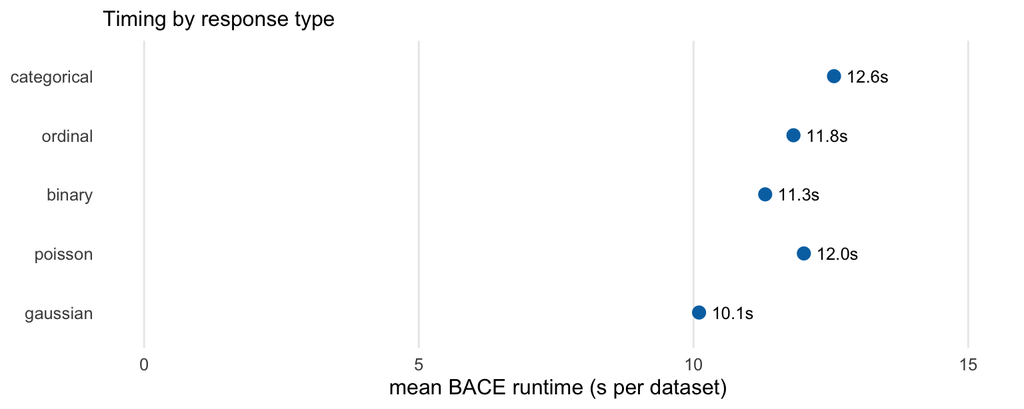

*Reproduce:* `Rscript dev/12_recovery_simulation.R`, `dev/13_response_type_simulation.R`, then render this file with `quarto render dev/simulation_results/SIMULATION_REPORT.qmd`.